# Networks: structure, evolution & processes

**Internet Analytics - Lab 2**

**Group:** *D*

**Names:**

- *Marc Bickel*
- *Cyril Cadoux*
- *Emma Lejal Glaude*

#### Instructions

*This is a template for part 3 of the lab. Clearly write your answers, comments and interpretations in Markodown cells. Don't forget that you can add $\LaTeX$ equations in these cells. Feel free to add or remove any cell.*

*Please properly comment your code. Code readability will be considered for grading. To avoid long cells of codes in the notebook, you can also embed long python functions and classes in a separate module. Don’t forget to hand in your module if that is the case. In multiple exercises, you are required to come up with your own method to solve various problems. Be creative and clearly motivate and explain your methods. Creativity and clarity will be considered for grading.*

## 2.3 Epidemics

#### Exercise 2.9: Simulate an epidemic outbreak

```python
import epidemics_helper

# Json libs
import json
from networkx.readwrite import json_graph

# Basic libs
import networkx as nx
import numpy as np
import matplotlib.pyplot as plt
import matplotlib.patches as mpatches

%matplotlib inline

# To avoid functions to print
from IPython.utils import io
```

##### Usefull functions :

```python
'''
Inside loops, this function prints the state, ie the percentage of iterations already accomplished
'''

def print_state(actual_i, modulo, iterations):

    if (actual_i % modulo == 0) :
        print ("\r", 100*float(actual_i)/iterations, " %", end='')
```

```python
'''
Reads and creates a Graph from a json file =
'''
def read_json_file(filename):

    with open(filename) as f:
        d = json.load(f)

    return json_graph.node_link_graph(d, directed = d["directed"], multigraph = d["multigraph"])
```

```python
#======== Creation of our work-tool ========

G = read_json_file("../data/nyc_augmented_network.json")
```

#### 2.9.1 Simulation of the epidemics for 100 days :

```python
#Create Object SimulationsSIR
sir = epidemics_helper.SimulationSIR(G, 10.0, 0.1)

#Call launch_epidemics(start node, max days) on the object
sir.launch_epidemic(23654, 100)
```

```
Epidemic stopped after 100.13 days | 100.13 days elapsed | 0.1% susceptible, 0.0% infected, 99.9% recovered
```

#### 2.9.2 Evolution over time

```python
#======== Initialization of 2 usefull lists ========


inf = sir.inf_time # Contains the infection-time of each node
death = sir.rec_time # Contains the death-time of each node
```

```python
# Store the percentage of Susceptible, Infected and Recovered people

nbS = np.array(())
nbI = np.array(())
nbR = np.array(())
```

```python
# ====== Computes the percentage of Susceptible, Infected and Recovered(dead) subject through time ======

time = np.linspace(0, 101, 1000)

n = float(len(inf))

for t in time :

    counterS = 0
    counterI = 0
    counterR = 0

    for i in inf :

        #At thime t, the subject is not yet infected => he is susceptible
        if (t < i):
            counterS = counterS +1

    for d in death :

        #At thime t, the subject is already dead => he is recovered
        if (t > d):
            counterR = counterR +1

    # The subject is not recovered, nor susceptible
    counterI = n - counterR - counterS

    nbS = np.append(nbS, counterS)
    nbI = np.append(nbI, counterI)
    nbR = np.append(nbR, counterR)

nbS = 100*nbS / n
nbI = 100*nbI / n
nbR = 100*nbR / n
```

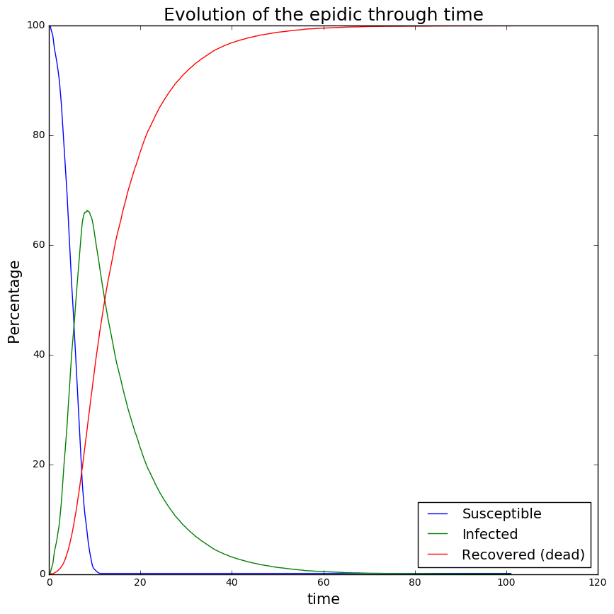

```python
#======== PLots the values computed in the cell above ========

plt.figure(figsize=(10, 10))

plt.plot(time, nbS)
plt.plot(time, nbI)
plt.plot(time, nbR)

plt.title("Evolution of the epidic through time",fontsize=18)
plt.xlabel("time", fontsize=15)
plt.ylabel("Percentage", fontsize=15)
unused = plt.legend(["Susceptible", "Infected", "Recovered (dead)"], loc='lower right', fontsize=14)
```

#### 2.9.3

The cell below computes the number of days befor 60% of people are infected and dead

```python
foundI = False
foundR = False

for i in range (0, len(nbI)):

    if (nbI[i] > 60 and not(foundI)):
        print("After ", time[i], " days, 60 people are infected")
        foundI = True

    if (nbR[i] > 60 and not(foundR)):
        print("After ", time[i], " days, 60 people are dead")
        foundR = True

    if (foundI and foundR) : break
```

```
After  6.87487487487  days, 60 people are infected
After  14.4574574575  days, 60 people are dead
```